BIF-7900 · Bioinformatique I · Statistiques avec R

# Solutionnaire du TP2

# À votre tour

## 1. ANOVA sur la longueur de la nageoire

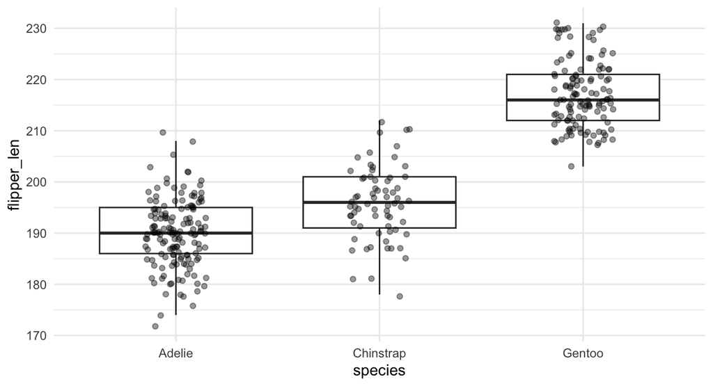

```r
ggplot(manchots, aes(species, flipper_len)) +
  geom_boxplot(outlier.shape = NA) +
  geom_jitter(width = 0.15, alpha = 0.4)
```

```r
modele_aov <- aov(flipper_len ~ species, data = manchots)
summary(modele_aov)
```

```
#>              Df Sum Sq Mean Sq F value Pr(>F)
#> species       2  52473   26237   594.8 <2e-16 ***
#> Residuals   339  14953      44
#> ---
#> Signif. codes:  0 '***' 0.001 '**' 0.01 '*' 0.05 '.' 0.1 ' ' 1
#> 2 observations deleted due to missingness
```

`Df` = 2 : 3 espèces − 1. Le message `2 observations deleted due to missingness` indique que 2 manchots sans mesure ont été écartés. La p-value est minuscule : au moins une espèce a une longueur moyenne différente.

## 2. Quelles espèces diffèrent ?

```r
TukeyHSD(modele_aov)
```

```
#>   Tukey multiple comparisons of means
#>     95% family-wise confidence level
#>
#> Fit: aov(formula = flipper_len ~ species, data = manchots)
#>
#> $species
#>                       diff       lwr       upr p adj
#> Chinstrap-Adelie  5.869887  3.586583  8.153191     0
#> Gentoo-Adelie    27.233349 25.334376 29.132323     0
#> Gentoo-Chinstrap 21.363462 19.000841 23.726084     0
```

Les trois paires diffèrent (p ajustée < 0.001). Les nageoires des Gentoo dépassent celles des Adélie d’environ **27 mm** (IC 95 % : 25 à 29 mm).

## 3. Conditions et Kruskal-Wallis

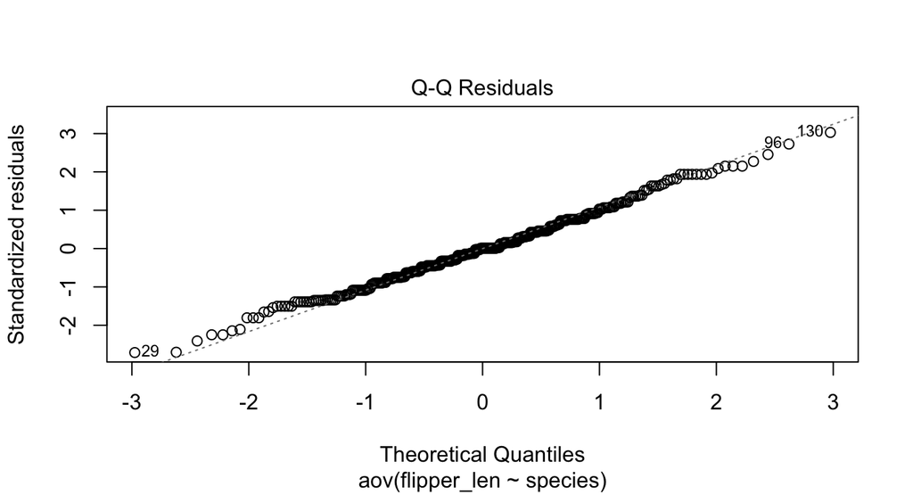

```r
plot(modele_aov, which = 2)
```

```r
leveneTest(flipper_len ~ factor(species), data = manchots)
```

```
#> Levene's Test for Homogeneity of Variance (center = median)
#>        Df F value Pr(>F)
#> group   2  0.3306 0.7188
#>       339
```

```r
kruskal.test(flipper_len ~ species, data = manchots)
```

```
#>
#>  Kruskal-Wallis rank sum test
#>
#> data:  flipper_len by species
#> Kruskal-Wallis chi-squared = 244.89, df = 2, p-value < 2.2e-16
```

Les résidus suivent bien la droite du Q-Q plot. Levene ne rejette pas l’égalité des variances. Kruskal-Wallis conduit à la même conclusion : l’effet de l’espèce est massif, il ne dépend pas du test.

## 4. Régression de la masse sur la nageoire

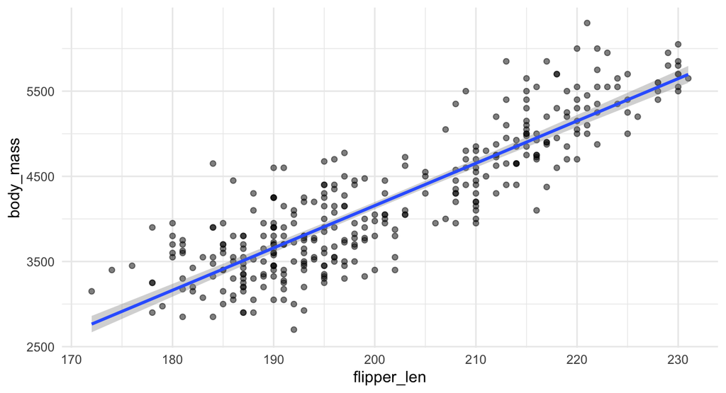

```r
ggplot(manchots, aes(flipper_len, body_mass)) +
  geom_point(alpha = 0.5) +
  geom_smooth(method = "lm")
```

```r
modele <- lm(body_mass ~ flipper_len, data = manchots)
summary(modele)
```

```
#>
#> Call:
#> lm(formula = body_mass ~ flipper_len, data = manchots)
#>
#> Residuals:
#>      Min       1Q   Median       3Q      Max
#> -1058.80  -259.27   -26.88   247.33  1288.69
#>
#> Coefficients:
#>              Estimate Std. Error t value Pr(>|t|)
#> (Intercept) -5780.831    305.815  -18.90   <2e-16 ***
#> flipper_len    49.686      1.518   32.72   <2e-16 ***
#> ---
#> Signif. codes:  0 '***' 0.001 '**' 0.01 '*' 0.05 '.' 0.1 ' ' 1
#>
#> Residual standard error: 394.3 on 340 degrees of freedom
#>   (2 observations deleted due to missingness)
#> Multiple R-squared:  0.759,  Adjusted R-squared:  0.7583
#> F-statistic:  1071 on 1 and 340 DF,  p-value: < 2.2e-16
```

```r
nobs(modele)
```

```
#> [1] 342
```

- **Pente** : 49.7 **g par mm** de nageoire, très significative
- **R²** = 0.76 : la longueur de la nageoire explique 76 % de la variance de la masse
- **342 manchots** utilisés : 2 ont été écartés (`2 observations deleted due to missingness`)

## 5. Les résidus

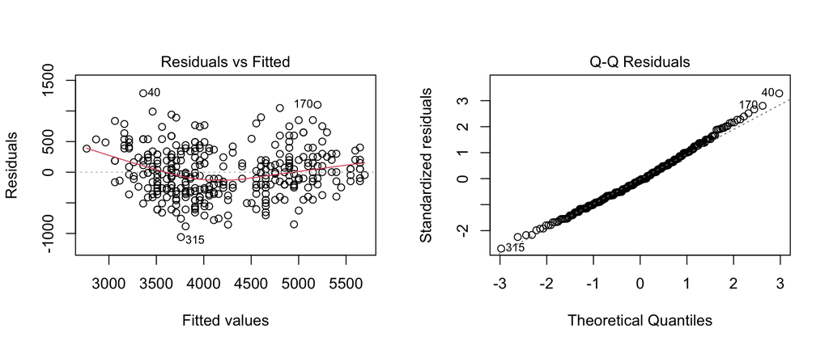

```r
par(mfrow = c(1, 2))
plot(modele, which = 1:2)
```

Le Q-Q plot est satisfaisant. Le graphique des résidus montre une légère courbure (résidus positifs aux extrémités) : la relation n’est pas parfaitement linéaire, en partie parce que les trois espèces forment des nuages distincts. Rien de grave pour une première analyse, mais un modèle avec l’espèce serait plus juste.

## 6. Le paradoxe de Simpson

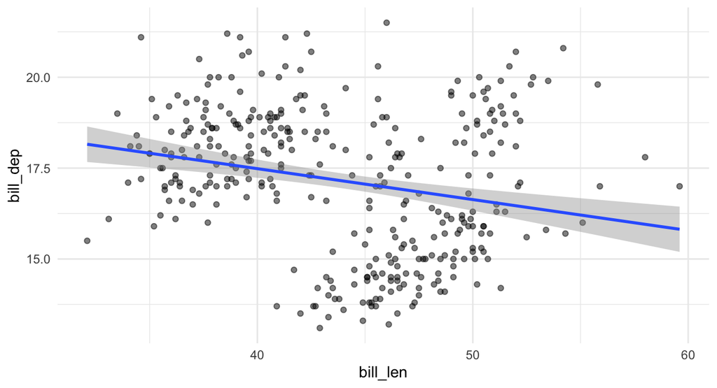

```r
ggplot(manchots, aes(bill_len, bill_dep)) +
  geom_point(alpha = 0.5) +
  geom_smooth(method = "lm")
```

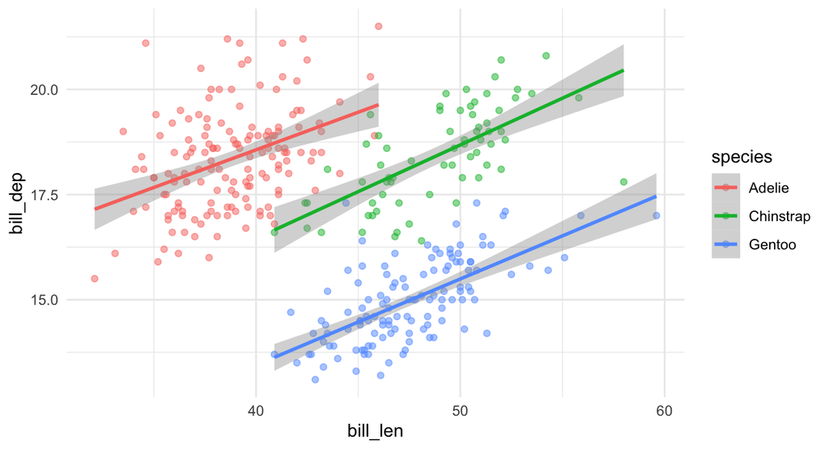

```r
ggplot(manchots, aes(bill_len, bill_dep, colour = species)) +
  geom_point(alpha = 0.5) +
  geom_smooth(method = "lm")
```

```r
coef(lm(bill_dep ~ bill_len, data = manchots))
```

```
#> (Intercept)    bill_len
#> 20.88546832 -0.08502128
```

```r
coef(lm(bill_dep ~ bill_len + species, data = manchots))
```

```
#>      (Intercept)         bill_len speciesChinstrap    speciesGentoo
#>       10.5921805        0.1998943       -1.9331943       -5.1060201
```

Tous ensemble, la pente est **négative** (−0.09 mm par mm) ; à espèce égale, elle est **positive** (+0.20 mm par mm). Les Gentoo ont un bec long mais peu profond, les Adélie un bec court mais profond : mélanger les espèces crée une tendance négative qui n’existe dans **aucune** d’elles. Une variable oubliée (l’espèce) peut inverser une conclusion, sans aucun message.

# Et si… ?

## 1. L’année, numérique ou facteur

```r
summary(aov(body_mass ~ year, data = manchots))
```

```
#>              Df    Sum Sq Mean Sq F value Pr(>F)
#> year          1    390726  390726   0.607  0.437
#> Residuals   340 218916972  643873
#> 2 observations deleted due to missingness
```

```r
summary(aov(body_mass ~ factor(year), data = manchots))
```

```
#>               Df    Sum Sq Mean Sq F value Pr(>F)
#> factor(year)   2   1138872  569436   0.885  0.414
#> Residuals    339 218168825  643566
#> 2 observations deleted due to missingness
```

`Df` = 1 avec l’année numérique : `aov()` ajuste une **droite** (une tendance linéaire dans le temps). `Df` = 2 avec `factor(year)` : on compare les **3 années** comme trois groupes. Pour la question « la masse diffère-t-elle selon l’année ? », c’est `factor(year)`. Ici, aucune des deux n’est significative, mais avec un effet non monotone (une année atypique au milieu), seule la version facteur le verrait.

## 2. Trois t-tests

```r
1 - 0.95^3
```

```
#> [1] 0.142625
```

Environ **14 %**, au lieu de 5 %. C’est pourquoi on fait une ANOVA, puis des comparaisons **ajustées** (Tukey).

## 3. Une nageoire de 150 mm

```r
predict(modele, newdata = tibble(flipper_len = 150))
```

```
#>        1
#> 1672.004
```

```r
range(manchots$flipper_len, na.rm = TRUE)
```

```
#> [1] 172 231
```

Environ 1.7 kg, mais 150 mm est **hors de l’étendue des données** (172 à 231 mm). Le modèle n’a jamais vu de manchot aussi petit : rien ne garantit que la relation reste linéaire. R ne prévient pas.

## 4. Corrélation négative entre longueur et profondeur du bec

```r
cor.test(manchots$bill_len, manchots$bill_dep)
```

```
#>
#>  Pearson's product-moment correlation
#>
#> data:  manchots$bill_len and manchots$bill_dep
#> t = -4.4591, df = 340, p-value = 1.12e-05
#> alternative hypothesis: true correlation is not equal to 0
#> 95 percent confidence interval:
#>  -0.3328072 -0.1323004
#> sample estimates:
#>        cor
#> -0.2350529
```

```r
manchots |> summarise(r = cor(bill_len, bill_dep, use = "complete.obs"), .by = species)
```

```
#> # A tibble: 3 × 2
#>   species       r
#>   <chr>     <dbl>
#> 1 Adelie    0.391
#> 2 Gentoo    0.643
#> 3 Chinstrap 0.654
```

Non : c’est le paradoxe de Simpson de la question 6. Dans **chaque** espèce, la corrélation est positive (0.39 à 0.65). La corrélation globale négative vient du mélange des espèces. Une corrélation significative ne dit rien de la cause, ni même du sens de la relation à l’intérieur des groupes.

## 5. Le niveau de référence dans `lm()`

```r
coef(lm(body_mass ~ species, data = manchots))
```

```
#>      (Intercept) speciesChinstrap    speciesGentoo
#>       3700.66225         32.42598       1375.35401
```

```r
manchots |> summarise(moyenne = mean(body_mass, na.rm = TRUE), .by = species)
```

```
#> # A tibble: 3 × 2
#>   species   moyenne
#>   <chr>       <dbl>
#> 1 Adelie      3701.
#> 2 Gentoo      5076.
#> 3 Chinstrap   3733.
```

`Adelie` est le **premier niveau** (ordre alphabétique) : c’est la **référence**. L’ordonnée à l’origine est la masse moyenne des Adélie (3701 g) ; `speciesChinstrap` (+32 g) et `speciesGentoo` (+1375 g) sont des **différences** par rapport aux Adélie. C’est exactement la logique du `log2FoldChange` de DESeq2 (TP3).